# Michael Waldron CMSC320 final project: An analysis on the Universal Crime Report

## Hypothesis testing

I’d like to do a correlation test to determine whether a state’s stance on the death penalty effects the rate of homicide. I will conduct this test both by individual state and on the national level over time. Our null hypothesis to test against for both is the absence of a relationship.

First, we need to add another column corresponding to whether each state has the death penalty at any given year. We will need to do this manually, but the information can be found here: https://deathpenaltyinfo.org/states-and-without-death-penalty. I began by adding an entire column labeled TRUE, then changed appropriate entries to FALSE based on if/when the state revoked the death penalty.

```r
#Preparing the new data frame
death_df <- UCR_df %>%
  filter(state != "US Total") %>%
  subset(select = c(state,year, population, homicide, homicide_rate))

death_df$death_penalty <- TRUE

death_df <- death_df %>%
  mutate(death_penalty = ifelse((state == "Alaska") |
                                  (state == "Conneticut" & year >= 2012) |
                                  (state == "Hawaii") |
                                  (state == "Illinois" & year >= 2011) |
                                  (state == "Iowa" & year >= 1965) |
                                  (state == "Maine") |
                                  (state == "Maryland" & year >= 2013) |
                                  (state == "Massachusetts" & year >= 1984) |
                                  (state == "Michigan") |
                                  (state == "Minnesota") |
                                  (state == "New Jersey" & year >= 2007) |
                                  (state == "New Mexico" & year >= 2009) |
                                  (state == "New York" & year >= 2007) |
                                  (state == "North Dakota" & year >= 1973) |
                                  (state == "Rhode Island" & year >= 1984) |
                                  (state == "Vermont" & year >= 1964) |
                                  (state == "West Virginia" & year >= 1965) |
                                  (state == "Wisconsin") |
                                  (state == "District of Columbia" & year >= 1981), FALSE, TRUE))

death_df %>%
  head(n=10)
```

```
##      state year population homicide homicide_rate death_penalty
## 1  Alabama 1960    3266740      406          12.4          TRUE
## 2  Alabama 1961    3302000      427          12.9          TRUE
## 3  Alabama 1962    3358000      316           9.4          TRUE
## 4  Alabama 1963    3347000      340          10.2          TRUE
## 5  Alabama 1964    3407000      316           9.3          TRUE
## 6  Alabama 1965    3462000      395          11.4          TRUE
## 7  Alabama 1966    3517000      384          10.9          TRUE
## 8  Alabama 1967    3540000      415          11.7          TRUE
## 9  Alabama 1968    3566000      421          11.8          TRUE
## 10 Alabama 1969    3531000      485          13.7          TRUE
```

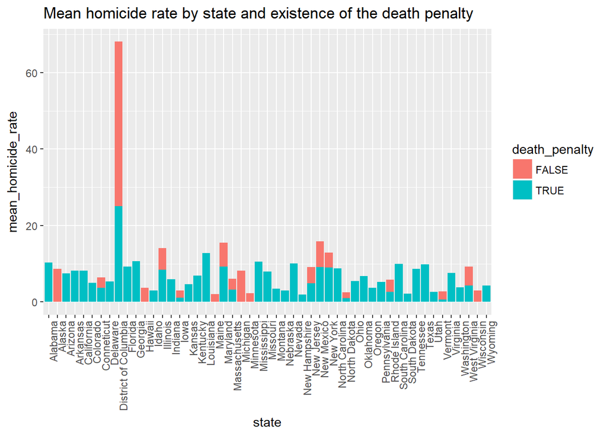

```r
#Visualizations
death_by_state <- death_df %>%
  group_by(state, death_penalty) %>%
  summarize(mean_homicide_rate = mean(homicide_rate))

death_by_state %>%
  ggplot(aes(x=state, y=mean_homicide_rate, fill=death_penalty)) +
  geom_bar(stat="identity") +
  ggtitle("Mean homicide rate by state and existence of the death penalty") +
  theme(axis.text.x = element_text(angle = 90, hjust = 1))
```

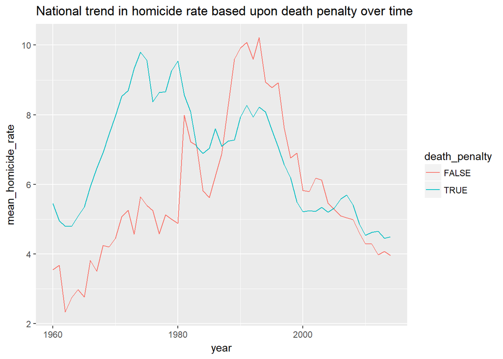

```r
death_by_year <- death_df %>%
  group_by(year, death_penalty) %>%
  summarize(mean_homicide_rate = mean(homicide_rate))

death_by_year %>%
  ggplot(aes(x=year, y=mean_homicide_rate, color=death_penalty)) +
  geom_line() +
  ggtitle("National trend in homicide rate based upon death penalty over time")
```

```r
#Testing
#For the tests we will need to convert the logcial values to numeric entries

cols <- sapply(death_by_state, is.logical)
death_by_state[,cols] <- lapply(death_by_state[,cols], as.numeric)

cols <- sapply(death_by_year, is.logical)
death_by_year[,cols] <- lapply(death_by_year[,cols], as.numeric)

cor.test(death_by_state$death_penalty, death_by_state$mean_homicide_rate)
```

```
##
##  Pearson's product-moment correlation
##
## data:  death_by_state$death_penalty and death_by_state$mean_homicide_rate
## t = 0.24996, df = 62, p-value = 0.8034
## alternative hypothesis: true correlation is not equal to 0
## 95 percent confidence interval:
##  -0.2157626  0.2753909
## sample estimates:
##        cor
## 0.03172954
```

```r
cor.test(death_by_year$death_penalty, death_by_year$mean_homicide_rate)
```

```
##
##  Pearson's product-moment correlation
##
## data:  death_by_year$death_penalty and death_by_year$mean_homicide_rate
## t = 2.8792, df = 108, p-value = 0.004808
## alternative hypothesis: true correlation is not equal to 0
## 95 percent confidence interval:
##  0.08394807 0.43260730
## sample estimates:
##       cor
## 0.2669928
```

## Machine learning

Now that we know there is a correlation between the number of states with/without the death penalty and homicide rate over time, let’s use cross validation to see how accurately we can predict whether a state has the death penalty using the mean homicide rate and year. I will compare both a logistic regression model and decision tree.

```r
#This is an example of k-fold cross validation, with k=10
fold_indices <- cvFolds(n=nrow(death_by_year), K=10)

error_rates <- sapply(1:10, function(fold_index) {
  test_indices <- which(fold_indices$which == fold_index)
  test_set <- death_by_year[test_indices,] #[row=test_indices, columns=all]
  train_set <- death_by_year[-test_indices,]

  logis_fit <- glm(death_penalty~., data=train_set, family="binomial") #death_penalty~. <- predict y=death_penalty based upon all other variables (year, mean_homicide_rate)
  logis_pred <- ifelse(predict(logis_fit, newdata=test_set, type="response") > 0.5, 0,1)
  logis_error <- mean(test_set$death_penalty != logis_pred)

  tree_fit <- tree(as.factor(death_penalty)~., data=train_set)
  pruned_tree <- prune.tree(tree_fit, best=3)

  tree_pred <- predict(pruned_tree, newdata=test_set, type="class")
  tree_error <- mean(test_set$death_penalty != tree_pred)
  c(logis_error, tree_error)
  })

rownames(error_rates) <- c("logis", "tree")
error_rates <- as.data.frame(t(error_rates))

error_rates <- error_rates %>%
  mutate(fold=1:n()) %>%
  gather(method,error,-fold)

error_rates
```

```
##    fold method      error
## 1     1  logis 0.63636364
## 2     2  logis 0.54545455
## 3     3  logis 0.54545455
## 4     4  logis 0.54545455
## 5     5  logis 0.54545455
## 6     6  logis 0.45454545
## 7     7  logis 0.54545455
## 8     8  logis 0.54545455
## 9     9  logis 0.45454545
## 10   10  logis 0.45454545
## 11    1   tree 0.72727273
## 12    2   tree 0.09090909
## 13    3   tree 0.72727273
## 14    4   tree 0.18181818
## 15    5   tree 0.72727273
## 16    6   tree 0.00000000
## 17    7   tree 0.72727273
## 18    8   tree 0.81818182
## 19    9   tree 0.63636364
## 20   10   tree 0.18181818
```

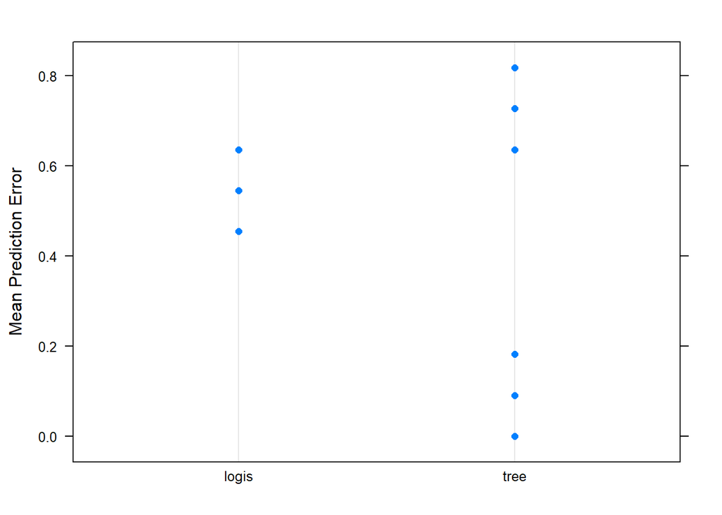

```r
dotplot(error~method, data=error_rates, ylab="Mean Prediction Error")
```

```r
lm(error~method, data=error_rates) %>%
  tidy()
```

```
##          term    estimate  std.error statistic      p.value
## 1 (Intercept)  0.52727273 0.07351218  7.172590 1.118734e-06
## 2  methodtree -0.04545455 0.10396192 -0.437223 6.671501e-01
```

## Insights

I’d like to begin with some criticisms of the UCR, addressing the grain of salt I alluded to in the introduction. The UCR only counts crime reports that are cleared by an arrest, meaning unsolved and unreported crime is not included in the data. However, attempted crime is included in the data, provided there was an arrest. The UCR is NOT mandatory, meaning even more data could be missing. Furthermore, because reporting data to the UCR is optional, and the responsibility of reporting falls to the local police, there have been cases of data being altered. Some police jurisdictions might have political motives for reporting more or less crime than actually took place (although this is very rare today). Another quirk of UCR data is reliant upon something called the hierarchy rule. The order in which I listed the crimes above is intentional, according to a hierarchy of perceived severity. The rule states that if multiple crimes are committed by the same person, only the crime with the highest severity will be recorded. One side effect of this is larceny of any kind is more severe than motor vehicle theft (according to the UCR) so if a criminal steals a pack of cigarettes from a store clerk, then steals a car to escape, the cigarette theft will be the only crime included in our data. Also, the value of the theft that occurred is not included in UCR data. Finally, federal crimes (such as bank robberies) are not included in the UCR. While the list of complaints does continue, these are the shortcomings I find most important to mention, in terms of data collection. I will also reiterate that while the UCR is far from perfect, it shouldn’t be ignored as the UCR is not without strengths. The most immediate strengths being the data is cheap to collect and free to access for anyone with an internet connection. Knowledge of these criticisms comes from my Criminological and Criminal Justice Research Methods class with Laure Brooks at UMD, but if any readers want to do their own research on how the UCR works this would be a good place to start: https://www.ncjrs.gov/App/Publications/abstract.aspx?ID=93896.

## Definitions

The following is copied exactly from https://www.ucrdatatool.gov/offenses.cfm

Criminal Homicide: a.) Murder and nonnegligent manslaughter: the willful (nonnegligent) killing of one human being by another. Deaths caused by negligence, attempts to kill, assaults to kill, suicides, and accidental deaths are excluded. The program classifies justifiable homicides separately and limits the definition to: (1) the killing of a felon by a law enforcement officer in the line of duty; or (2) the killing of a felon, during the commission of a felony, by a private citizen. b.) Manslaughter by negligence: the killing of another person through gross negligence. Deaths of persons due to their own negligence, accidental deaths not resulting from gross negligence, and traffic fatalities are not included in the category Manslaughter by Negligence.

Forcible Rape/Legacy Rape: The carnal knowledge of a female forcibly and against her will. Rapes by force and attempts or assaults to rape, regardless of the age of the victim, are included. Statutory offenses (no force used-victim under age of consent) are excluded.

Revised Rape: Penetration, no matter how slight, of the vagina or anus with any body part or object, or oral penetration by a sex organ of another person, without the consent of the victim. Attempts or assaults to commit rape are also included; however, statutory rape and incest are excluded. In December 2011, the UCR program changed its definition of SRS rape to this revised definition. This change can be seen in the UCR data starting in 2013. Any data reported under the older definition of rape will be called “legacy rape”.

Robbery: The taking or attempting to take anything of value from the care, custody, or control of a person or persons by force or threat of force or violence and/or by putting the victim in fear.

Aggravated assault: An unlawful attack by one person upon another for the purpose of inflicting severe or aggravated bodily injury. This type of assault usually is accompanied by the use of a weapon or by means likely to produce death or great bodily harm. Simple assaults are excluded.

Burglary (breaking or entering): The unlawful entry of a structure to commit a felony or a theft. Attempted forcible entry is included.

Larceny: The unlawful taking, carrying, leading, or riding away of property from the possession or constructive possession of another. Examples are thefts of bicycles, motor vehicle parts and accessories, shoplifting, pocketpicking, or the stealing of any property or article that is not taken by force and violence or by fraud. Attempted larcenies are included. Embezzlement, confidence games, forgery, check fraud, etc., are excluded.

Motor Vehicle Theft: The theft or attempted theft of a motor vehicle. A motor vehicle is self-propelled and runs on land surface and not on rails. Motorboats, construction equipment, airplanes, and farming equipment are specifically excluded from this category.